First, let us load the data and necessary packages:

```r
load("ames_train.Rdata")
library(MASS)
library(dplyr)
```

```r
library(ggplot2)
library(Metrics)
summary(ames_train)
```

```
##       PID                 area          price         MS.SubClass
##  Min.   :5.263e+08   Min.   : 334   Min.   : 12789   Min.   : 20.00
##  1st Qu.:5.285e+08   1st Qu.:1092   1st Qu.:129763   1st Qu.: 20.00
##  Median :5.354e+08   Median :1411   Median :159467   Median : 50.00
##  Mean   :7.059e+08   Mean   :1477   Mean   :181190   Mean   : 57.15
##  3rd Qu.:9.071e+08   3rd Qu.:1743   3rd Qu.:213000   3rd Qu.: 70.00
##  Max.   :1.007e+09   Max.   :4676   Max.   :615000   Max.   :190.00
##
##    MS.Zoning    Lot.Frontage       Lot.Area       Street     Alley
##  A (agr):  0   Min.   : 21.00   Min.   :  1470   Grvl:  3   Grvl: 33
##  C (all):  9   1st Qu.: 57.00   1st Qu.:  7314   Pave:997   Pave: 34
##  FV     : 56   Median : 69.00   Median :  9317              NA's:933
##  I (all):  1   Mean   : 69.21   Mean   : 10352
##  RH     :  7   3rd Qu.: 80.00   3rd Qu.: 11650
##  RL     :772   Max.   :313.00   Max.   :215245
##  RM     :155   NA's   :167
##  Lot.Shape Land.Contour  Utilities      Lot.Config  Land.Slope  Neighborhood
##  IR1:338   Bnk: 33      AllPub:1000   Corner :173   Gtl:962    NAmes  :155
##  IR2: 30   HLS: 38      NoSeWa:   0   CulDSac: 76   Mod: 33    CollgCr: 85
##  IR3:  3   Low: 20      NoSewr:   0   FR2    : 36   Sev:  5    Somerst: 74
##  Reg:629   Lvl:909                    FR3    :  5              OldTown: 71
##                                       Inside :710              Sawyer : 61
##                                                                Edwards: 60
##                                                                (Other):494
##   Condition.1   Condition.2   Bldg.Type    House.Style   Overall.Qual
##  Norm   :875   Norm   :988   1Fam  :823   1Story :521   Min.   : 1.000
##  Feedr  : 53   Feedr  :  6   2fmCon: 20   2Story :286   1st Qu.: 5.000
##  Artery : 23   Artery :  2   Duplex: 35   1.5Fin : 98   Median : 6.000
##  RRAn   : 14   PosN   :  2   Twnhs : 38   SLvl   : 41   Mean   : 6.095
##  PosN   : 11   PosA   :  1   TwnhsE: 84   SFoyer : 36   3rd Qu.: 7.000
##  RRAe   : 11   RRNn   :  1                2.5Unf : 10   Max.   :10.000
##  (Other): 13   (Other):  0                (Other):  8
##   Overall.Cond     Year.Built   Year.Remod.Add   Roof.Style    Roof.Matl
##  Min.   :1.000   Min.   :1872   Min.   :1950   Flat   :  9   CompShg:984
##  1st Qu.:5.000   1st Qu.:1955   1st Qu.:1966   Gable  :775   Tar&Grv: 11
##  Median :5.000   Median :1975   Median :1992   Gambrel:  8   WdShake:  2
##  Mean   :5.559   Mean   :1972   Mean   :1984   Hip    :204   WdShngl:  2
##  3rd Qu.:6.000   3rd Qu.:2001   3rd Qu.:2004   Mansard:  4   Metal  :  1
##  Max.   :9.000   Max.   :2010   Max.   :2010   Shed   :  0   ClyTile:  0
##                                                              (Other):  0
```

[output cut: 81 more lines]

```
##  Min.   :  0.000   Ex  :  1   GdPrv: 43   Elev:  0     Min.   :    0.00
##  1st Qu.:  0.000   Fa  :  1   GdWo : 37   Gar2:  2     1st Qu.:    0.00
##  Median :  0.000   Gd  :  1   MnPrv:120   Othr:  1     Median :    0.00
##  Mean   :  1.463   TA  :  0   MnWw :  2   Shed: 25     Mean   :   45.81
##  3rd Qu.:  0.000   NA's:997   NA's :798   TenC:  1     3rd Qu.:    0.00
##  Max.   :800.000                          NA's:971     Max.   :15500.00
##
##     Mo.Sold          Yr.Sold       Sale.Type   Sale.Condition
##  Min.   : 1.000   Min.   :2006   WD     :863   Abnorml: 61
##  1st Qu.: 4.000   1st Qu.:2007   New    : 79   AdjLand:  2
##  Median : 6.000   Median :2008   COD    : 27   Alloca :  4
##  Mean   : 6.243   Mean   :2008   ConLD  :  7   Family : 17
##  3rd Qu.: 8.000   3rd Qu.:2009   ConLw  :  6   Normal :834
##  Max.   :12.000   Max.   :2010   Con    :  5   Partial: 82
##                                  (Other): 13
```

# 1

Make a labeled histogram (with 30 bins) of the ages of the houses in the data set, and describe the distribution.

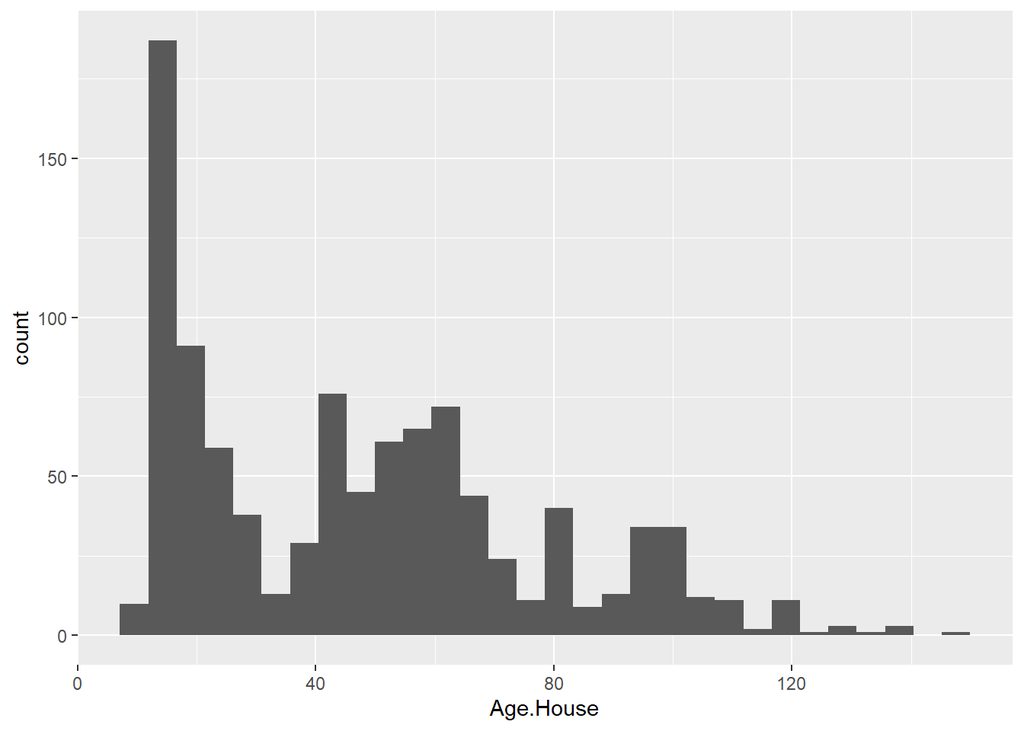

```r
# type your code for Question 1 here, and Knit
ames_train = ames_train %>%
  mutate('Age.House' = as.integer(format(Sys.Date(), '%Y')) - Year.Built)


ggplot(data = ames_train, aes(x = Age.House)) +
  geom_histogram(bins = 30)
```

Fisrt, I calculated the age of each house as the difference between actual year and Year.Built.

The distribution of age houses is right skewed, so that means there are more new houses than old ones.

# 2

The mantra in real estate is “Location, Location, Location!” Make a graphical display that relates a home price to its neighborhood in Ames, Iowa. Which summary statistics are most appropriate to use for determining the most expensive, least expensive, and most heterogeneous (having the most variation in housing price) neighborhoods? Report which neighborhoods these are based on the summary statistics of your choice. Report the value of your chosen summary statistics for these neighborhoods.

```r
# type your code for Question 2 here, and Knit
ames_sum_price = ames_train %>%
  group_by(Neighborhood) %>%
  summarise(mean = mean(price), sd = sd(price), max = max(price), min = min(price))
ames_sum_price
```

```
## # A tibble: 27 x 5
##    Neighborhood    mean     sd    max    min
##    <fct>          <dbl>  <dbl>  <int>  <int>
##  1 Blmngtn      198635. 26455. 246990 172500
##  2 Blueste      125800  10381. 137000 116500
##  3 BrDale        98930  13338. 125500  83000
##  4 BrkSide      122473. 37310. 207000  39300
##  5 ClearCr      193154. 48069. 277000 107500
##  6 CollgCr      196951. 52786. 475000 110000
##  7 Crawfor      204197. 71268. 392500  96500
##  8 Edwards      136322. 54852. 415000  61500
##  9 Gilbert      193328. 41190. 377500 133000
## 10 Greens       198562. 29063. 214000 155000
## # ... with 17 more rows
```

```r
ames_sum_price %>%
  filter(max == max(ames_sum_price$max))
```

```
## # A tibble: 1 x 5
##   Neighborhood    mean      sd    max    min
##   <fct>          <dbl>   <dbl>  <int>  <int>
## 1 NridgHt      333647. 105089. 615000 173000
```

```r
ames_sum_price %>%
  filter(min == min(ames_sum_price$min))
```

```
## # A tibble: 1 x 5
##   Neighborhood    mean     sd    max   min
##   <fct>          <dbl>  <dbl>  <int> <int>
## 1 OldTown      120226. 36430. 265979 12789
```

```r
ames_sum_price %>%
  filter(sd == max(ames_sum_price$sd))
```

```
## # A tibble: 1 x 5
##   Neighborhood    mean      sd    max    min
##   <fct>          <dbl>   <dbl>  <int>  <int>
## 1 StoneBr      339316. 123459. 591587 180000
```

The most expensive houses are in NridgHt.

The cheapest houses are in OldTown.

The most variation in housing price is in StoneBr.

# 3

Which variable has the largest number of missing values? Explain why it makes sense that there are so many missing values for this variable.

```r
# type your code for Question 3 here, and Knit
sapply(ames_train, function(x) sum(is.na(x)))
```

```
##             PID            area           price     MS.SubClass       MS.Zoning
##               0               0               0               0               0
##    Lot.Frontage        Lot.Area          Street           Alley       Lot.Shape
##             167               0               0             933               0
##    Land.Contour       Utilities      Lot.Config      Land.Slope    Neighborhood
##               0               0               0               0               0
##     Condition.1     Condition.2       Bldg.Type     House.Style    Overall.Qual
##               0               0               0               0               0
##    Overall.Cond      Year.Built  Year.Remod.Add      Roof.Style       Roof.Matl
##               0               0               0               0               0
##    Exterior.1st    Exterior.2nd    Mas.Vnr.Type    Mas.Vnr.Area      Exter.Qual
##               0               0               0               7               0
##      Exter.Cond      Foundation       Bsmt.Qual       Bsmt.Cond   Bsmt.Exposure
##               0               0              21              21              21
##  BsmtFin.Type.1    BsmtFin.SF.1  BsmtFin.Type.2    BsmtFin.SF.2     Bsmt.Unf.SF
##              21               1              21               1               1
##   Total.Bsmt.SF         Heating      Heating.QC     Central.Air      Electrical
##               1               0               0               0               0
##     X1st.Flr.SF     X2nd.Flr.SF Low.Qual.Fin.SF  Bsmt.Full.Bath  Bsmt.Half.Bath
##               0               0               0               1               1
##       Full.Bath       Half.Bath   Bedroom.AbvGr   Kitchen.AbvGr    Kitchen.Qual
##               0               0               0               0               0
##   TotRms.AbvGrd      Functional      Fireplaces    Fireplace.Qu     Garage.Type
##               0               0               0             491              46
##   Garage.Yr.Blt   Garage.Finish     Garage.Cars     Garage.Area     Garage.Qual
##              48              46               1               1              47
##     Garage.Cond     Paved.Drive    Wood.Deck.SF   Open.Porch.SF  Enclosed.Porch
##              47               0               0               0               0
##     X3Ssn.Porch    Screen.Porch       Pool.Area         Pool.QC           Fence
##               0               0               0             997             798
##    Misc.Feature        Misc.Val         Mo.Sold         Yr.Sold       Sale.Type
##             971               0               0               0               0
##  Sale.Condition       Age.House
##               0               0
```

The variable with the largest number of missing values is **Pool.QC**. This means that most houses do not have pool.

# 4

We want to predict the natural log of the home prices. Candidate explanatory variables are lot size in square feet (Lot.Area), slope of property (Land.Slope), original construction date (Year.Built), remodel date (Year.Remod.Add), and the number of bedrooms above grade (Bedroom.AbvGr). Pick a model selection or model averaging method covered in the Specialization, and describe how this method works. Then, use this method to find the best multiple regression model for predicting the natural log of the home prices.

```r
# type your code for Question 4 here, and Knit
ames_train = ames_train %>%
  mutate(l_price = log(price))

ames_train.4 = ames_train %>%
  select(l_price, Lot.Area, Land.Slope, Year.Built, Year.Remod.Add, Bedroom.AbvGr)

ames_train.4 %>%
  summary()
```

```
##     l_price          Lot.Area      Land.Slope   Year.Built   Year.Remod.Add
##  Min.   : 9.456   Min.   :  1470   Gtl:962    Min.   :1872   Min.   :1950
##  1st Qu.:11.773   1st Qu.:  7314   Mod: 33    1st Qu.:1955   1st Qu.:1966
##  Median :11.980   Median :  9317   Sev:  5    Median :1975   Median :1992
##  Mean   :12.018   Mean   : 10352              Mean   :1972   Mean   :1984
##  3rd Qu.:12.269   3rd Qu.: 11650              3rd Qu.:2001   3rd Qu.:2004
##  Max.   :13.329   Max.   :215245              Max.   :2010   Max.   :2010
##  Bedroom.AbvGr
##  Min.   :0.000
##  1st Qu.:2.000
##  Median :3.000
##  Mean   :2.806
##  3rd Qu.:3.000
##  Max.   :6.000
```

```r
ames_train.4 %>%
  select(l_price, Lot.Area, Year.Built, Year.Remod.Add, Bedroom.AbvGr) %>%
  cor()
```

```
##                  l_price    Lot.Area   Year.Built Year.Remod.Add Bedroom.AbvGr
## l_price        1.0000000 0.242495902  0.628744054     0.60672600    0.19816996
## Lot.Area       0.2424959 1.000000000  0.007922578     0.02804909    0.15340857
## Year.Built     0.6287441 0.007922578  1.000000000     0.61650258   -0.02627679
## Year.Remod.Add 0.6067260 0.028049086  0.616502580     1.00000000    0.01667897
## Bedroom.AbvGr  0.1981700 0.153408568 -0.026276794     0.01667897    1.00000000
```

```r
lm.full.4 = lm(l_price ~ ., data = ames_train.4)
summary(lm.full.4)
```

```
##
## Call:
## lm(formula = l_price ~ ., data = ames_train.4)
##
## Residuals:
##     Min      1Q  Median      3Q     Max
## -2.0878 -0.1651 -0.0211  0.1657  0.9945
##
## Coefficients:
##                  Estimate Std. Error t value Pr(>|t|)
## (Intercept)    -1.371e+01  8.574e-01 -15.996  < 2e-16 ***
## Lot.Area        1.028e-05  1.106e-06   9.296  < 2e-16 ***
## Land.SlopeMod   1.384e-01  4.991e-02   2.773  0.00565 **
## Land.SlopeSev  -4.567e-01  1.514e-01  -3.016  0.00263 **
## Year.Built      6.049e-03  3.788e-04  15.968  < 2e-16 ***
## Year.Remod.Add  6.778e-03  5.468e-04  12.395  < 2e-16 ***
## Bedroom.AbvGr   8.686e-02  1.077e-02   8.063 2.12e-15 ***
## ---
## Signif. codes:  0 '***' 0.001 '**' 0.01 '*' 0.05 '.' 0.1 ' ' 1
##
## Residual standard error: 0.279 on 993 degrees of freedom
## Multiple R-squared:  0.5625, Adjusted R-squared:  0.5598
## F-statistic: 212.8 on 6 and 993 DF,  p-value: < 2.2e-16
```

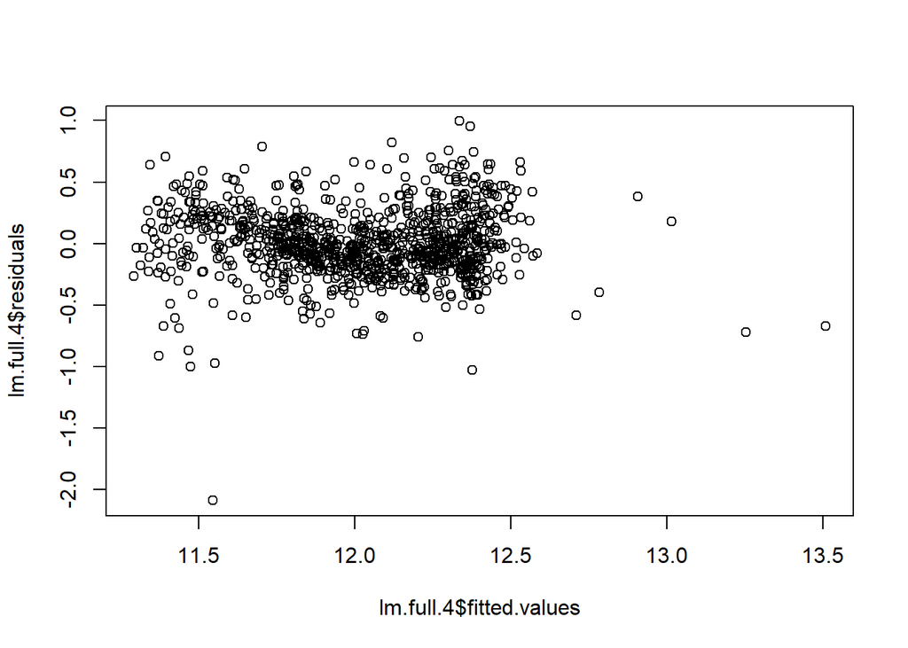

```r
plot(lm.full.4$residuals ~ lm.full.4$fitted.values)
```

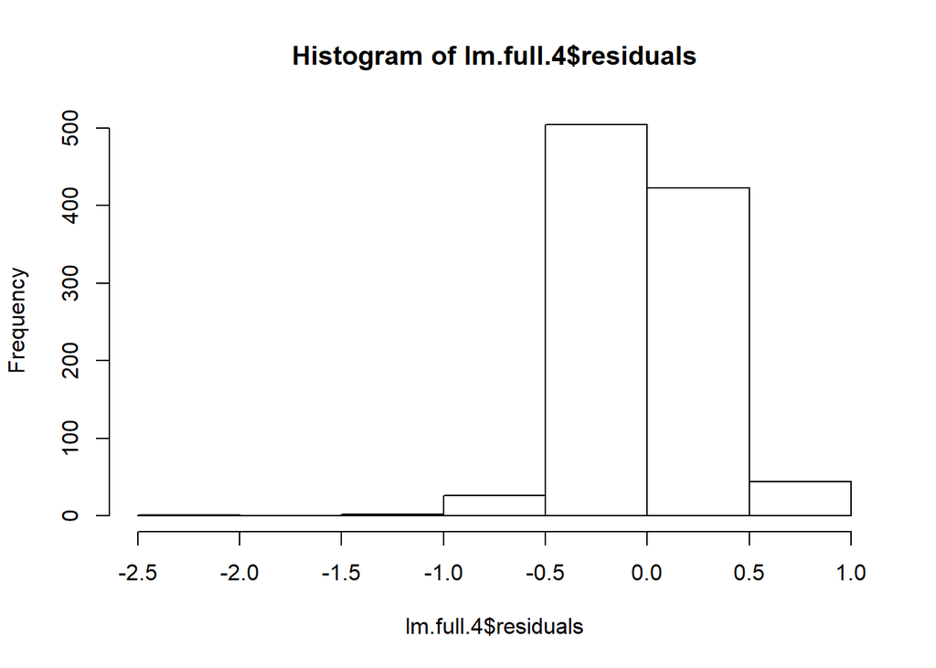

```r
hist(lm.full.4$residuals)
```

Analyzing p-value predictors, all predictors are significance.

# 5

Which home has the largest squared residual in the previous analysis (Question 4)? Looking at all the variables in the data set, can you explain why this home stands out from the rest (what factors contribute to the high squared residual and why are those factors relevant)?

```r
# type your code for Question 5 here, and Knit
max.out.index = which(lm.full.4$residuals == max(lm.full.4$residuals))
ames_train.4[max.out.index,]
```

```
## # A tibble: 1 x 6
##   l_price Lot.Area Land.Slope Year.Built Year.Remod.Add Bedroom.AbvGr
##     <dbl>    <int> <fct>           <int>          <int>         <int>
## 1    13.3    12720 Mod              2003           2003             1
```

```r
q1 = quantile(lm.full.4$residuals, 0.25)[[1]]
q3 = quantile(lm.full.4$residuals, 0.75)[[1]]
factor = 1.5

iqr = q3 - q1
max.value = q3 + factor*iqr
min.value = q1 - factor*iqr

quantile(lm.full.4$residuals, c(0.25, 0.75))
```

```
##        25%        75%
## -0.1650932  0.1656578
```

```r
index.no.outliers = which(lm.full.4$residuals > min.value & lm.full.4$residuals < max.value)
ames_train.4.no.out = ames_train.4[index.no.outliers, ]
summary(ames_train.4.no.out)
```

```
##     l_price         Lot.Area     Land.Slope   Year.Built   Year.Remod.Add
##  Min.   :10.82   Min.   : 1470   Gtl:945    Min.   :1872   Min.   :1950
##  1st Qu.:11.78   1st Qu.: 7294   Mod: 28    1st Qu.:1956   1st Qu.:1966
##  Median :11.98   Median : 9272   Sev:  2    Median :1975   Median :1992
##  Mean   :12.02   Mean   : 9963              Mean   :1973   Mean   :1984
##  3rd Qu.:12.26   3rd Qu.:11624              3rd Qu.:2001   3rd Qu.:2004
##  Max.   :13.29   Max.   :56600              Max.   :2010   Max.   :2010
##  Bedroom.AbvGr
##  Min.   :0.000
##  1st Qu.:2.000
##  Median :3.000
##  Mean   :2.813
##  3rd Qu.:3.000
##  Max.   :6.000
```

```r
ames_train.4.no.out %>%
  filter(l_price > 13 & l_price < 13.5)
```

```
## # A tibble: 7 x 6
##   l_price Lot.Area Land.Slope Year.Built Year.Remod.Add Bedroom.AbvGr
##     <dbl>    <int> <fct>           <int>          <int>         <int>
## 1    13.1    11778 Gtl              2008           2008             3
## 2    13.1    14300 Mod              2003           2004             3
## 3    13.1    13891 Gtl              2007           2007             3
## 4    13.2    16052 Gtl              2006           2006             4
## 5    13.3    51974 Gtl              2006           2007             4
## 6    13.0    13870 Gtl              2006           2007             3
## 7    13.2    53504 Mod              2003           2003             4
```

```r
ames_train.4.no.out %>%
  filter(Land.Slope == 'Mod' & Bedroom.AbvGr == 1)
```

```
## # A tibble: 1 x 6
##   l_price Lot.Area Land.Slope Year.Built Year.Remod.Add Bedroom.AbvGr
##     <dbl>    <int> <fct>           <int>          <int>         <int>
## 1    12.0    13050 Mod              1963           1963             1
```

# 6

Use the same model selection method you chose in Question 4 to again find the best multiple regression model to predict the natural log of home prices, but this time **replacing Lot.Area with log(Lot.Area)**. Do you arrive at a model including the same set of predictors?

```r
# type your code for Question 6 here, and Knit
ames_train = ames_train %>%
  mutate(l_Lot.Area = log(Lot.Area))

ames_train.5 = ames_train %>%
  select(l_price, l_Lot.Area, Land.Slope, Year.Built, Year.Remod.Add, Bedroom.AbvGr)

ames_train.5 %>%
  summary()
```

```
##     l_price         l_Lot.Area     Land.Slope   Year.Built   Year.Remod.Add
##  Min.   : 9.456   Min.   : 7.293   Gtl:962    Min.   :1872   Min.   :1950
##  1st Qu.:11.773   1st Qu.: 8.898   Mod: 33    1st Qu.:1955   1st Qu.:1966
##  Median :11.980   Median : 9.140   Sev:  5    Median :1975   Median :1992
##  Mean   :12.018   Mean   : 9.092              Mean   :1972   Mean   :1984
##  3rd Qu.:12.269   3rd Qu.: 9.363              3rd Qu.:2001   3rd Qu.:2004
##  Max.   :13.329   Max.   :12.280              Max.   :2010   Max.   :2010
##  Bedroom.AbvGr
##  Min.   :0.000
##  1st Qu.:2.000
##  Median :3.000
##  Mean   :2.806
##  3rd Qu.:3.000
##  Max.   :6.000
```

```r
lm.full.5 = lm(l_price ~ ., data = ames_train.5)
summary(lm.full.5)
```

```
##
## Call:
## lm(formula = l_price ~ ., data = ames_train.5)
##
## Residuals:
##      Min       1Q   Median       3Q      Max
## -2.14050 -0.15650 -0.01561  0.15350  0.90854
##
## Coefficients:
##                  Estimate Std. Error t value Pr(>|t|)
## (Intercept)    -1.553e+01  8.197e-01 -18.947  < 2e-16 ***
## l_Lot.Area      2.442e-01  1.708e-02  14.297  < 2e-16 ***
## Land.SlopeMod   1.151e-01  4.734e-02   2.431   0.0152 *
## Land.SlopeSev  -6.554e-02  1.222e-01  -0.536   0.5917
## Year.Built      5.981e-03  3.597e-04  16.628  < 2e-16 ***
## Year.Remod.Add  6.734e-03  5.190e-04  12.975  < 2e-16 ***
## Bedroom.AbvGr   5.909e-02  1.055e-02   5.599  2.8e-08 ***
## ---
## Signif. codes:  0 '***' 0.001 '**' 0.01 '*' 0.05 '.' 0.1 ' ' 1
##
## Residual standard error: 0.2649 on 993 degrees of freedom
## Multiple R-squared:  0.6056, Adjusted R-squared:  0.6032
## F-statistic: 254.1 on 6 and 993 DF,  p-value: < 2.2e-16
```

Using log(Lot.Area) I had a model with a higher Adjusted R-Square.

# 7

Do you think it is better to log transform Lot.Area, in terms of assumptions for linear regression? Make graphs of the predicted values of log home price versus the true values of log home price for the regression models selected for Lot.Area and log(Lot.Area). Referencing these two plots, provide a written support that includes a quantitative justification for your answer in the first part of question 7.

```r
# type your code for Question 7 here, and Knit
test.data.5 = ames_train.5 %>%
  select(l_Lot.Area, Land.Slope, Year.Built, Year.Remod.Add, Bedroom.AbvGr)

y.pred.5 = predict(lm.full.5, test.data.5)
```

```r
test.data.4 = ames_train.4 %>%
  select(Lot.Area, Land.Slope, Year.Built, Year.Remod.Add, Bedroom.AbvGr)

y.pred.4 = predict(lm.full.4, test.data.4)
```

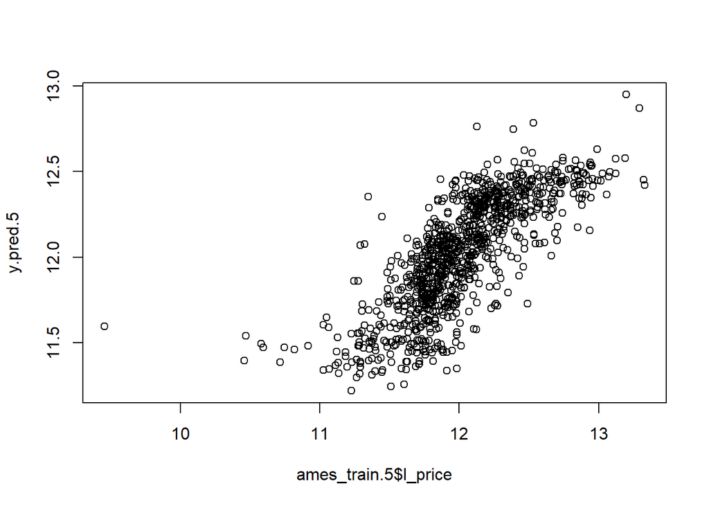

```r
plot(ames_train.5$l_price, y.pred.5)
```

```r
mse(ames_train.5$l_price, y.pred.5)
```

```
## [1] 0.06970397
```

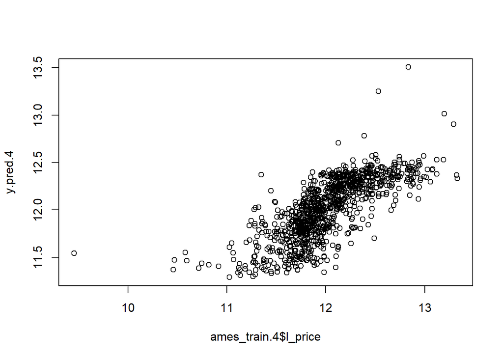

```r
plot(ames_train.4$l_price, y.pred.4)
```

```r
mse(ames_train.4$l_price, y.pred.4)
```

```
## [1] 0.07732215
```